# Primary RNA-seq QC and RUV analysis

29 十月, 2026

```r
library(DESeq2)
library(tidyverse)
library(reactable)
library(plotly)
library(RUVSeq)
library(edgeR)
disease_colors <- c("control" = "#0072B2", "T2D case" = "#D55E00")
timepoint_colors <- c("baseline" = "#009E73", "follow-up" = "#CC79A7")
outlier_colors <- c("No" = "#7A7A7A", "Potential" = "#E69F00", "Extreme" = "#D55E00")
outlier_binary_colors <- c("No" = "#7A7A7A", "Flagged" = "#D55E00")
timepoint_shapes <- c("baseline" = 19, "follow-up" = 21)
outlier_shapes <- c("No" = 16, "Potential" = 17, "Extreme" = 15)
cchc_theme <- function() {
  theme_bw(base_size = 12) +
    theme(plot.title = element_text(face = "bold"),
      axis.title = element_text(face = "bold"),
      strip.text = element_text(face = "bold"),
      legend.position = "top",
      panel.grid.minor = element_blank())}
theme_set(cchc_theme())
format_plotly <- function(p){
  p |>
    layout(hovermode = "closest", font = list(size = 12), margin = list(l = 70, r = 40, b = 60, t = 40)) |>
    config(displaylogo = FALSE, responsive = TRUE)}
```

```r
qc <- read_tsv("../output/qc/sample_qc_summary.tsv", show_col_types = FALSE) |>
  mutate(library_size_input_million = salmon_processed_fragments / 1e6,
    library_size_output_million = salmon_mapped_fragments / 1e6,
    rrna_mean_pct = (rrna_r1_pct + rrna_r2_pct) / 2,
    hbrna_mean_pct = (hbrna_r1_pct + hbrna_r2_pct) / 2)
sample_metadata <- read_csv("../config/PRJNA762935.csv", show_col_types = FALSE) |>
  dplyr::select(run = Run, age = AGE, sex)
sample_info <- read_tsv("../config/samples.tsv", show_col_types = FALSE) |>
  left_join(sample_metadata, by = "run")
stopifnot(!anyDuplicated(sample_metadata$run), all(sample_info$run %in% sample_metadata$run))
## The Snakemake tximport wrapper doesn't keep sample names,
## so they're restored here using the sample order defined in the workflow
txi <- readRDS("../data/tximport/tximport_gene.rds")
stopifnot(ncol(txi$counts) == nrow(sample_info))
for (assay_name in intersect(c("counts", "abundance", "length"), names(txi))) {
  colnames(txi[[assay_name]]) <- sample_info$run}
gene_counts <- txi$counts
stopifnot(identical(colnames(gene_counts), sample_info$run))
txi_ruv <- readRDS("../data/tximport/tximport_gene_lengthscaled.rds")
stopifnot(ncol(txi_ruv$counts) == nrow(sample_info))
for (assay_name in intersect(c("counts", "abundance", "length"), names(txi_ruv))) {
  colnames(txi_ruv[[assay_name]]) <- sample_info$run}
## The gene filter (keep) is defined on txi and later applied to txi_ruv,
## so both objects need the same gene order
stopifnot(identical(colnames(txi_ruv$counts), sample_info$run),
  identical(rownames(txi_ruv$counts), rownames(gene_counts)))
```

# Data Summary

Samples included in this analysis. Each individual has one baseline and one follow-up sample.

```r
tibble(Metric = c("Samples", "Individuals", "Baseline samples", "Follow-up samples"),
  Value = c(nrow(qc), n_distinct(qc$individual), sum(qc$timepoint == "baseline"), sum(qc$timepoint == "follow-up"))) |>
  reactable(pagination = FALSE, bordered = TRUE, striped = TRUE, highlight = TRUE)
```

| Metric | Value |
| --- | --- |
| Samples | 116 |
| Individuals | 58 |
| Baseline samples | 58 |
| Follow-up samples | 58 |

Number of samples in each disease state and timepoint.

```r
qc |>
  dplyr::count(disease_state, timepoint, name = "Samples") |>
  reactable(pagination = FALSE, bordered = TRUE, striped = TRUE, highlight = TRUE)
```

| disease_state | timepoint | Samples |
| --- | --- | --- |
| T2D case | baseline | 25 |
| T2D case | follow-up | 25 |
| control | baseline | 33 |
| control | follow-up | 33 |

## Sample QC Table

Main QC metrics for each sample, taken from Salmon quantification and from alignment of reads to rRNA and haemoglobin reference sequences.

```r
sample_qc <- qc |>
  transmute(run, sample, individual, disease_state, timepoint,
    library_size_input_million = round(library_size_input_million, 2),
    library_size_output_million = round(library_size_output_million, 2),
    mapping_rate = round(mapping_rate, 2),
    library_type,
    library_compatible_pct = round(library_compatible_pct, 2),
    decoy_pct = round(decoy_pct, 2),
    fragment_length_mean = round(fragment_length_mean, 2),
    fragment_length_sd = round(fragment_length_sd, 2),
    rrna_mean_pct = round(rrna_mean_pct, 2),
    hbrna_mean_pct = round(hbrna_mean_pct, 2))
reactable(sample_qc,
  searchable = TRUE, sortable = TRUE, resizable = TRUE, filterable = TRUE,
  showPageSizeOptions = TRUE, defaultPageSize = 10, striped = TRUE, highlight = TRUE,
  columns = list(
    run = colDef(name = "Run"),
    sample = colDef(name = "Sample"),
    individual = colDef(name = "Individual"),
    disease_state = colDef(name = "Disease state"),
    timepoint = colDef(name = "Timepoint"),
    library_size_input_million = colDef(name = "Input (M fragments)"),
    library_size_output_million = colDef(name = "Mapped (M fragments)"),
    mapping_rate = colDef(name = "Mapping (%)"),
    library_type = colDef(name = "Library type"),
    library_compatible_pct = colDef(name = "Compatible (%)"),
    decoy_pct = colDef(name = "Decoy (%)"),
    fragment_length_mean = colDef(name = "Fragment mean"),
    fragment_length_sd = colDef(name = "Fragment SD"),
    rrna_mean_pct = colDef(name = "rRNA (%)"),
    hbrna_mean_pct = colDef(name = "HbRNA (%)")))
```

| Run | Sample | Individual | Disease state | Timepoint | Input (M fragments) | Mapped (M fragments) | Mapping (%) | Library type | Compatible (%) | Decoy (%) | Fragment mean | Fragment SD | rRNA (%) | HbRNA (%) |
| --- | --- | --- | --- | --- | --- | --- | --- | --- | --- | --- | --- | --- | --- | --- |
| SRR15881871 | GSM5576716 | case subject 1 | T2D case | baseline | 23.1 | 7.28 | 31.5 | ISR | 97.27 | 66.99 | 183.17 | 65.16 | 7.83 | 0.28 |
| SRR15881872 | GSM5576717 | case subject 2 | T2D case | baseline | 12.98 | 4.93 | 37.95 | ISR | 97.75 | 60.8 | 165.31 | 57.98 | 5.18 | 0.04 |
| SRR15881873 | GSM5576718 | case subject 3 | T2D case | baseline | 25.06 | 6.02 | 24.01 | ISR | 95.87 | 73.56 | 192.55 | 70.59 | 4.42 | 0.07 |
| SRR15881874 | GSM5576719 | case subject 4 | T2D case | baseline | 10.87 | 4.94 | 45.46 | ISR | 98.08 | 53.18 | 166.82 | 59.41 | 4 | 0.04 |
| SRR15881875 | GSM5576720 | case subject 5 | T2D case | baseline | 17.17 | 4.47 | 26.03 | ISR | 96.32 | 72.05 | 185.4 | 70.48 | 4.96 | 0.14 |
| SRR15881876 | GSM5576721 | case subject 6 | T2D case | baseline | 21.36 | 6.44 | 30.17 | ISR | 96.98 | 67.99 | 188.32 | 69.93 | 6.69 | 0.19 |
| SRR15881877 | GSM5576722 | case subject 7 | T2D case | baseline | 18.98 | 6.73 | 35.47 | ISR | 97.56 | 63.34 | 185.18 | 68.76 | 4.72 | 0.11 |
| SRR15881878 | GSM5576723 | case subject 8 | T2D case | baseline | 28.55 | 0.47 | 1.66 | ISR | 13.28 | 87.43 | 162.81 | 55.08 | 84.69 | 10.59 |
| SRR15881879 | GSM5576724 | case subject 9 | T2D case | baseline | 20.23 | 9.94 | 49.14 | ISR | 98.22 | 49.12 | 172.35 | 53.88 | 4.26 | 0.05 |
| SRR15881880 | GSM5576725 | case subject 10 | T2D case | baseline | 13.07 | 4.39 | 33.6 | ISR | 97.87 | 65.29 | 180.98 | 65.69 | 12.29 | 0.18 |

[output cut: 106 more lines]

## Salmon Library Type

Library type inferred by Salmon, used to check whether all libraries share the same strand protocol.

```r
qc |>
  dplyr::count(library_type, name = "Samples") |>
  reactable(pagination = FALSE, bordered = TRUE, striped = TRUE, highlight = TRUE,
    columns = list(library_type = colDef(name = "Library type")))
```

| Library type | Samples |
| --- | --- |
| ISR | 116 |

# Salmon QC

Sample-level metrics from Salmon quantification. Unless noted, samples are ordered by the metric shown and coloured by timepoint.

## Mapping Rate

Percentage of processed fragments that Salmon mapped. Low values can reflect contamination, degraded RNA or reads from outside the annotated transcriptome.

```r
p <- qc |>
  arrange(mapping_rate) |>
  mutate(sample_order = row_number(),
    hover = paste0("Run: ", run, "<br>Individual: ", individual, "<br>Group: ", disease_state,
      "<br>Timepoint: ", timepoint, "<br>Mapping rate: ", round(mapping_rate, 2), "%")) |>
  ggplot(aes(x = sample_order, y = mapping_rate, color = timepoint, text = hover)) +
  geom_point(size = 2.4, alpha = 0.8) +
  scale_color_manual(values = timepoint_colors) +
  labs(x = "Samples ordered by mapping rate", y = "Salmon mapping rate (%)", color = "Timepoint")
format_plotly(ggplotly(p, tooltip = "text"))
```

[interactive chart not shown]

## Library Size

Fragments processed by Salmon (input) and fragments mapped (output). Comparing the two separates low sequencing depth from fragment loss during mapping.

```r
library_size_plot <- qc |>
  arrange(library_size_input_million) |>
  mutate(sample_order = row_number()) |>
  dplyr::select(run, individual, disease_state, timepoint, sample_order, library_size_input_million,
    library_size_output_million) |>
  pivot_longer(cols = c(library_size_input_million, library_size_output_million),
    names_to = "library_stage", values_to = "library_size_million") |>
  mutate(library_stage = recode(library_stage, library_size_input_million = "Input",
      library_size_output_million = "Output"),
    hover = paste0("Run: ", run, "<br>Individual: ", individual, "<br>Group: ", disease_state,
      "<br>Timepoint: ", timepoint, "<br>Stage: ", library_stage,
      "<br>Library size: ", round(library_size_million, 2), " million fragments"))
p <- library_size_plot |>
  ggplot(aes(x = sample_order, y = library_size_million, color = timepoint, text = hover)) +
  geom_point(size = 2.4, alpha = 0.8) +
  scale_color_manual(values = timepoint_colors) +
  facet_wrap(~ library_stage, ncol = 1, scales = "free_y") +
  labs(x = "Samples ordered by input library size", y = "Library size (million fragments)", color = "Timepoint")
format_plotly(ggplotly(p, tooltip = "text"))
```

[interactive chart not shown]

### Input vs Output

Input against output library size, coloured by disease state and shaped by timepoint.

```r
p <- qc |>
  mutate(hover = paste0("Run: ", run, "<br>Individual: ", individual, "<br>Group: ", disease_state,
    "<br>Timepoint: ", timepoint,
    "<br>Input: ", round(library_size_input_million, 2), " M",
    "<br>Output: ", round(library_size_output_million, 2), " M",
    "<br>Mapping: ", round(mapping_rate, 2), "%")) |>
  ggplot(aes(x = library_size_input_million, y = library_size_output_million, color = disease_state,
    shape = timepoint, text = hover)) +
  geom_point(size = 2.5, alpha = 0.8) +
  scale_color_manual(values = disease_colors) +
  scale_shape_manual(values = timepoint_shapes) +
  labs(x = "Input library size (million processed fragments)",
    y = "Output library size (million mapped fragments)",
    color = "Disease state", shape = "Timepoint")
format_plotly(ggplotly(p, tooltip = "text"))
```

[interactive chart not shown]

## Library Compatibility

Percentage of mapped fragments consistent with the library type inferred by Salmon. Low values can point to differences in library structure or mapping behaviour.

```r
p <- qc |>
  arrange(library_compatible_pct) |>
  mutate(sample_order = row_number(),
    hover = paste0("Run: ", run, "<br>Individual: ", individual, "<br>Group: ", disease_state,
      "<br>Timepoint: ", timepoint, "<br>Compatible: ", round(library_compatible_pct, 2), "%")) |>
  ggplot(aes(x = sample_order, y = library_compatible_pct, color = timepoint, text = hover)) +
  geom_point(size = 2.4, alpha = 0.8) +
  scale_color_manual(values = timepoint_colors) +
  labs(x = "Samples ordered by compatibility", y = "Library-compatible fragments (%)", color = "Timepoint")
format_plotly(ggplotly(p, tooltip = "text"))
```

[interactive chart not shown]

## Decoy Alignment

Percentage of processed fragments that aligned better to decoy sequences than to the annotated transcriptome. High values suggest more off-target or ambiguous alignment.

```r
p <- qc |>
  arrange(decoy_pct) |>
  mutate(sample_order = row_number(),
    hover = paste0("Run: ", run, "<br>Individual: ", individual, "<br>Group: ", disease_state,
      "<br>Timepoint: ", timepoint, "<br>Decoy: ", round(decoy_pct, 2), "%")) |>
  ggplot(aes(x = sample_order, y = decoy_pct, color = timepoint, text = hover)) +
  geom_point(size = 2.4, alpha = 0.8) +
  scale_color_manual(values = timepoint_colors) +
  labs(x = "Samples ordered by decoy proportion", y = "Decoy fragments (%)", color = "Timepoint")
format_plotly(ggplotly(p, tooltip = "text"))
```

[interactive chart not shown]

## Fragment Length

Mean fragment length estimated by Salmon. Unusually short or long fragments can reflect differences in library preparation or RNA integrity.

```r
p <- qc |>
  arrange(fragment_length_mean) |>
  mutate(sample_order = row_number(),
    hover = paste0("Run: ", run, "<br>Individual: ", individual, "<br>Group: ", disease_state,
      "<br>Timepoint: ", timepoint, "<br>Mean fragment length: ", round(fragment_length_mean, 2), " bp")) |>
  ggplot(aes(x = sample_order, y = fragment_length_mean, color = timepoint, text = hover)) +
  geom_point(size = 2.4, alpha = 0.8) +
  scale_color_manual(values = timepoint_colors) +
  labs(x = "Samples ordered by fragment length", y = "Mean fragment length (bp)", color = "Timepoint")
format_plotly(ggplotly(p, tooltip = "text"))
```

[interactive chart not shown]

# Whole-blood QC

Whole-blood libraries can contain a large and variable share of ribosomal RNA (rRNA) and haemoglobin RNA (HbRNA) reads, which reduces the depth available for other genes and can add sample-level variation. Both were measured as the percentage of reads aligning to the relevant reference sequences, with R1 and R2 aligned separately. For each, the first plot shows the mean of R1 and R2, and the second compares R1 with R2 against the line y = x.

## rRNA

```r
p <- qc |>
  arrange(rrna_mean_pct) |>
  mutate(sample_order = row_number(),
    hover = paste0("Run: ", run, "<br>Individual: ", individual, "<br>Group: ", disease_state,
      "<br>Timepoint: ", timepoint, "<br>rRNA: ", round(rrna_mean_pct, 2), "%")) |>
  ggplot(aes(x = sample_order, y = rrna_mean_pct, color = timepoint, text = hover)) +
  geom_point(size = 2.4, alpha = 0.8) +
  scale_color_manual(values = timepoint_colors) +
  labs(x = "Samples ordered by rRNA content", y = "Mean rRNA mapping (%)", color = "Timepoint")
format_plotly(ggplotly(p, tooltip = "text"))
```

[interactive chart not shown]

```r
p <- qc |>
  mutate(hover = paste0("Run: ", run, "<br>Individual: ", individual, "<br>Timepoint: ", timepoint,
    "<br>R1: ", round(rrna_r1_pct, 2), "%", "<br>R2: ", round(rrna_r2_pct, 2), "%")) |>
  ggplot(aes(x = rrna_r1_pct, y = rrna_r2_pct, color = timepoint, text = hover)) +
  geom_point(size = 2.4, alpha = 0.8) +
  geom_abline(slope = 1, intercept = 0, linetype = 2) +
  scale_color_manual(values = timepoint_colors) +
  labs(x = "rRNA R1 (%)", y = "rRNA R2 (%)", color = "Timepoint")
format_plotly(ggplotly(p, tooltip = "text"))
```

[interactive chart not shown]

## HbRNA

```r
p <- qc |>
  arrange(hbrna_mean_pct) |>
  mutate(sample_order = row_number(),
    hover = paste0("Run: ", run, "<br>Individual: ", individual, "<br>Group: ", disease_state,
      "<br>Timepoint: ", timepoint, "<br>HbRNA: ", round(hbrna_mean_pct, 2), "%")) |>
  ggplot(aes(x = sample_order, y = hbrna_mean_pct, color = timepoint, text = hover)) +
  geom_point(size = 2.4, alpha = 0.8) +
  scale_color_manual(values = timepoint_colors) +
  labs(x = "Samples ordered by HbRNA content", y = "Mean HbRNA mapping (%)", color = "Timepoint")
format_plotly(ggplotly(p, tooltip = "text"))
```

[interactive chart not shown]

```r
p <- qc |>
  mutate(hover = paste0("Run: ", run, "<br>Individual: ", individual, "<br>Timepoint: ", timepoint,
    "<br>R1: ", round(hbrna_r1_pct, 2), "%", "<br>R2: ", round(hbrna_r2_pct, 2), "%")) |>
  ggplot(aes(x = hbrna_r1_pct, y = hbrna_r2_pct, color = timepoint, text = hover)) +
  geom_point(size = 2.4, alpha = 0.8) +
  geom_abline(slope = 1, intercept = 0, linetype = 2) +
  scale_color_manual(values = timepoint_colors) +
  labs(x = "HbRNA R1 (%)", y = "HbRNA R2 (%)", color = "Timepoint")
format_plotly(ggplotly(p, tooltip = "text"))
```

[interactive chart not shown]

# QC Summary

Minimum, median and maximum of each QC metric across all samples, as a reference for the per-sample values above.

```r
qc_summary <- qc |>
  summarise(across(c(library_size_input_million, library_size_output_million, mapping_rate,
      library_compatible_pct, decoy_pct, fragment_length_mean, fragment_length_sd, rrna_mean_pct, hbrna_mean_pct),
    list(min = ~ min(.x, na.rm = TRUE), median = ~ median(.x, na.rm = TRUE), max = ~ max(.x, na.rm = TRUE)))) |>
  pivot_longer(everything(), names_to = c("metric", ".value"), names_pattern = "(.+)_(min|median|max)$") |>
  mutate(across(c(min, median, max), ~ round(.x, 2)),
    metric = metric |> str_replace_all("_", " ") |> str_to_sentence()) |>
  rename(Metric = metric, Minimum = min, Median = median, Maximum = max)
reactable(qc_summary, pagination = FALSE, bordered = TRUE, striped = TRUE, highlight = TRUE)
```

| Metric | Minimum | Median | Maximum |
| --- | --- | --- | --- |
| Library size input million | 6.38 | 19.21 | 44.43 |
| Library size output million | 0.41 | 6.09 | 13.59 |
| Mapping rate | 1.24 | 36.2 | 66.99 |
| Library compatible pct | 10.98 | 97.8 | 99.53 |
| Decoy pct | 32.36 | 62.44 | 89.19 |
| Fragment length mean | 144.4 | 169.64 | 206.58 |
| Fragment length sd | 48.09 | 61.75 | 83.02 |
| Rrna mean pct | 2 | 4.95 | 87.62 |
| Hbrna mean pct | 0 | 0.06 | 10.59 |

# Expression-level Assessment

## Gene-level Expression Data

Gene-level counts were obtained from the tximport object generated by the Snakemake workflow. Salmon transcript-level estimates were summarised to genes using the GRCh38 annotation (countsFromAbundance = “no”).

```r
tibble(Metric = c("Imported samples", "Genes"), Value = c(ncol(gene_counts), nrow(gene_counts))) |>
  reactable(pagination = FALSE, bordered = TRUE, striped = TRUE, highlight = TRUE)
```

| Metric | Value |
| --- | --- |
| Imported samples | 116 |
| Genes | 35748 |

## Variance-stabilised Expression

Genes with at least 10 counts in at least five samples were kept, removing low-expression genes that add noise but carry little information. Counts were then transformed with DESeq2’s variance-stabilising transformation (VST), which reduces the dependence of the variance on the mean. The VST was calculated blind to sample groups, as appropriate for unsupervised QC.

```r
coldata <- as.data.frame(sample_info)
rownames(coldata) <- coldata$run
stopifnot(identical(rownames(coldata), colnames(txi$counts)))
dds <- DESeqDataSetFromTximport(txi = txi, colData = coldata, design = ~ 1)
keep <- rowSums(counts(dds) >= 10) >= 5
dds <- dds[keep, ]
vsd <- vst(dds, blind = TRUE)
vst_matrix <- assay(vsd)
tibble(Metric = c("Genes before filtering", "Genes retained for PCA", "Samples"),
  Value = c(nrow(gene_counts), nrow(vst_matrix), ncol(vst_matrix))) |>
  reactable(pagination = FALSE, bordered = TRUE, striped = TRUE, highlight = TRUE)
```

| Metric | Value |
| --- | --- |
| Genes before filtering | 35748 |
| Genes retained for PCA | 15018 |
| Samples | 116 |

## PCA

Principal component analysis (PCA) was performed on the VST expression matrix (centred, not scaled) to summarise the main sources of variation across samples. The percentage on each axis is the proportion of total variance explained by that PC.

```r
pca <- prcomp(t(vst_matrix), center = TRUE, scale. = FALSE)
variance_explained <- (pca$sdev^2 / sum(pca$sdev^2)) * 100
pca_data <- as.data.frame(pca$x[, 1:4, drop = FALSE]) |>
  rownames_to_column("run") |>
  left_join(sample_info, by = "run") |>
  mutate(hover = paste0("Run: ", run, "<br>Sample: ", sample, "<br>Individual: ", individual,
    "<br>Group: ", disease_state, "<br>Timepoint: ", timepoint, "<br>Age: ", age, "<br>Sex: ", sex))
```

### PCA Diagnostics

Points are coloured by disease state and shaped by timepoint, and grey lines join the two samples from each individual.

#### Variance Explained

Percentage of variance explained by the first 10 PCs.

```r
n_pc_shown <- min(10, length(variance_explained))
pca_variance <- tibble(PC = factor(paste0("PC", seq_len(n_pc_shown)), levels = paste0("PC", seq_len(n_pc_shown))),
  Variance = variance_explained[seq_len(n_pc_shown)])
plot_ly(data = pca_variance, x = ~PC, y = ~Variance, type = "bar",
  text = ~paste0(PC, ": ", round(Variance, 2), "%"), hoverinfo = "text") |>
  layout(xaxis = list(title = "Principal component"), yaxis = list(title = "Variance explained (%)")) |>
  format_plotly()
```

[interactive chart not shown]

#### PC1 vs PC2

```r
plot_pca_pair <- function(pc_x, pc_y) {
  pc_index <- as.integer(str_remove(c(pc_x, pc_y), "PC"))
  plot_data <- pca_data |>
    mutate(x = .data[[pc_x]], y = .data[[pc_y]],
      text = paste0(hover, "<br>", pc_x, ": ", round(x, 2), "<br>", pc_y, ": ", round(y, 2)))
  p <- ggplot(plot_data, aes(x, y)) +
    geom_line(aes(group = individual), color = "grey70", linewidth = 0.5, alpha = 0.5) +
    geom_point(aes(color = disease_state, shape = timepoint, text = text),
      data = dplyr::filter(plot_data, disease_state == "control"), size = 2.5, alpha = 0.85) +
    geom_point(aes(color = disease_state, shape = timepoint, text = text),
      data = dplyr::filter(plot_data, disease_state == "T2D case"), size = 2.5, alpha = 0.85) +
    scale_color_manual(values = disease_colors) +
    scale_shape_manual(values = timepoint_shapes) +
    labs(x = paste0(pc_x, " (", round(variance_explained[pc_index[1]], 1), "%)"),
      y = paste0(pc_y, " (", round(variance_explained[pc_index[2]], 1), "%)")) +
    cchc_theme()
  ## Replace the combined (disease state, timepoint) legend with two separate legends
  legend_key <- tibble(name = c(names(disease_colors), names(timepoint_shapes)),
    group = rep(c("Disease state", "Timepoint"), c(length(disease_colors), length(timepoint_shapes))),
    color = c(unname(disease_colors), rep("grey40", length(timepoint_shapes))),
    symbol = c(rep("circle", length(disease_colors)), "circle", "circle-open"))
  p <- plotly_build(ggplotly(p, tooltip = "text"))
  p$x$data <- lapply(p$x$data, function(tr) modifyList(tr, list(showlegend = FALSE)))
  legend_traces <- lapply(seq_len(nrow(legend_key)), function(i) {
    list(type = "scatter", mode = "markers", x = I(NA_real_), y = I(NA_real_), hoverinfo = "skip",
      name = legend_key$name[i], legendgroup = legend_key$group[i],
      legendgrouptitle = list(text = legend_key$group[i]), showlegend = TRUE,
      marker = list(color = legend_key$color[i], symbol = legend_key$symbol[i], size = 9))})
  p$x$data <- c(p$x$data, legend_traces)
  p$x$layout$legend <- modifyList(p$x$layout$legend,
    list(title = list(text = ""), itemclick = FALSE, itemdoubleclick = FALSE, tracegroupgap = 12))
  format_plotly(p)}
plot_pca_pair("PC1", "PC2")
```

[interactive chart not shown]

#### PC3 vs PC4

PC3 and PC4 are included because technical or sample-specific effects are not always captured by the first two PCs.

```r
plot_pca_pair("PC3", "PC4")
```

[interactive chart not shown]

# Robust Outlier Detection

Robust Z-scores were calculated for each sample on PC1-PC4 using the median and median absolute deviation (MAD), which are less affected by outlying samples than the mean and standard deviation. Absolute scores of at least 2.58 or 3.29 (the two-sided 1% and 0.1% tails of a standard normal distribution) were labelled potential and extreme outliers, respectively.

```r
## mad() is scaled by 1.4826 by default, so robust Z is on the same scale as a normal Z
potential_cutoff <- qnorm(0.995)
extreme_cutoff <- qnorm(0.9995)
outlier_levels <- c("No", "Potential", "Extreme")
robust_scores <- pca_data |>
  dplyr::select(run, PC1, PC2, PC3, PC4) |>
  pivot_longer(cols = PC1:PC4, names_to = "PC", values_to = "score") |>
  group_by(PC) |>
  mutate(pc_median = median(score, na.rm = TRUE),
    pc_mad = mad(score, na.rm = TRUE),
    robust_z = if_else(pc_mad > 0, (score - pc_median) / pc_mad, NA_real_),
    abs_robust_z = abs(robust_z),
    outlier_status = case_when(abs_robust_z >= extreme_cutoff ~ "Extreme",
      abs_robust_z >= potential_cutoff ~ "Potential",
      TRUE ~ "No"),
    outlier_status = factor(outlier_status, levels = outlier_levels)) |>
  ungroup() |>
  left_join(sample_info, by = "run") |>
  mutate(hover = paste0("Run: ", run, "<br>Individual: ", individual, "<br>", PC, ": ", round(score, 2),
    "<br>Robust Z: ", round(robust_z, 2), "<br>Status: ", outlier_status))
```

## Robust Z-score Distribution

Absolute robust Z-scores on PC1-PC4. Dashed and dotted lines mark the potential and extreme thresholds.

```r
plot_ly(data = robust_scores, x = ~PC, y = ~abs_robust_z, type = "scatter", mode = "markers",
  color = ~outlier_status, colors = outlier_colors, text = ~hover, hoverinfo = "text") |>
  layout(xaxis = list(title = "Principal component"),
    yaxis = list(title = "Absolute robust Z-score"),
    shapes = list(
      list(type = "line", xref = "paper", x0 = 0, x1 = 1, y0 = potential_cutoff, y1 = potential_cutoff,
        line = list(dash = "dash")),
      list(type = "line", xref = "paper", x0 = 0, x1 = 1, y0 = extreme_cutoff, y1 = extreme_cutoff,
        line = list(dash = "dot")))) |>
  format_plotly()
```

[interactive chart not shown]

## Outlier Summary

Each sample is assigned the most severe label it received on any of PC1-PC4, and the PCs involved are recorded.

```r
sample_outliers <- robust_scores |>
  group_by(run) |>
  summarise(max_abs_robust_z = max(abs_robust_z, na.rm = TRUE),
    flagged_pc = paste(PC[outlier_status != "No"], collapse = ", "),
    sample_outlier_status = case_when(any(outlier_status == "Extreme") ~ "Extreme",
      any(outlier_status == "Potential") ~ "Potential",
      TRUE ~ "No"),
    .groups = "drop") |>
  rename(outlier_status = sample_outlier_status) |>
  mutate(outlier_status = factor(outlier_status, levels = outlier_levels)) |>
  left_join(sample_info, by = "run") |>
  left_join(qc |> dplyr::select(run, library_size_input_million, library_size_output_million, mapping_rate,
    library_compatible_pct, decoy_pct, fragment_length_mean, rrna_mean_pct, hbrna_mean_pct), by = "run")
outlier_counts <- sample_outliers |>
  dplyr::count(outlier_status, name = "Samples")
reactable(outlier_counts, pagination = FALSE, bordered = TRUE, striped = TRUE, highlight = TRUE)
```

| outlier_status | Samples |
| --- | --- |
| No | 96 |
| Potential | 7 |
| Extreme | 13 |

# Flagged Sample Review

Samples labelled potential or extreme outliers (flagged samples) are listed with their metadata and QC metrics, to check whether a known biological or technical factor could account for their PCA position.

## Flagged Samples

Sorted by the maximum absolute robust Z-score across PC1-PC4.

```r
flagged_samples <- sample_outliers |>
  dplyr::filter(outlier_status != "No") |>
  mutate(max_abs_robust_z = round(max_abs_robust_z, 2),
    library_size_input_million = round(library_size_input_million, 2),
    library_size_output_million = round(library_size_output_million, 2),
    mapping_rate = round(mapping_rate, 2),
    library_compatible_pct = round(library_compatible_pct, 2),
    decoy_pct = round(decoy_pct, 2),
    fragment_length_mean = round(fragment_length_mean, 2),
    rrna_mean_pct = round(rrna_mean_pct, 2),
    hbrna_mean_pct = round(hbrna_mean_pct, 2)) |>
  arrange(desc(max_abs_robust_z)) |>
  dplyr::select(run, individual, disease_state, timepoint, age, sex, outlier_status, flagged_pc, max_abs_robust_z,
    library_size_input_million, library_size_output_million, mapping_rate, library_compatible_pct,
    decoy_pct, fragment_length_mean, rrna_mean_pct, hbrna_mean_pct)
reactable(flagged_samples,
  searchable = TRUE, sortable = TRUE, resizable = TRUE, filterable = TRUE,
  showPageSizeOptions = TRUE, defaultPageSize = 10, striped = TRUE, highlight = TRUE,
  columns = list(
    run = colDef(name = "Run"),
    individual = colDef(name = "Individual"),
    disease_state = colDef(name = "Disease state"),
    timepoint = colDef(name = "Timepoint"),
    age = colDef(name = "Age"),
    sex = colDef(name = "Sex"),
    outlier_status = colDef(name = "Outlier status"),
    flagged_pc = colDef(name = "Flagged PC"),
    max_abs_robust_z = colDef(name = "Max |robust Z|")))
```

| Run | Individual | Disease state | Timepoint | Age | Sex | Outlier status | Flagged PC | Max \|robust Z\| | library_size_input_million | library_size_output_million | mapping_rate | library_compatible_pct | decoy_pct | fragment_length_mean | rrna_mean_pct | hbrna_mean_pct |
| --- | --- | --- | --- | --- | --- | --- | --- | --- | --- | --- | --- | --- | --- | --- | --- | --- |
| SRR15881967 | control subject 13 | control | follow-up | 33 | female | Extreme | PC1, PC2 | 11.69 | 23.93 | 8.7 | 36.34 | 99.23 | 63.21 | 206.58 | 48.78 | 1.53 |
| SRR15881984 | control subject 30 | control | follow-up | 42 | female | Extreme | PC1, PC2 | 9.78 | 11.86 | 3.28 | 27.7 | 98.53 | 71.66 | 178.57 | 47.22 | 2.16 |
| SRR15881976 | control subject 22 | control | follow-up | 49 | female | Extreme | PC1, PC2 | 9.43 | 12.9 | 3.56 | 27.6 | 98.45 | 71.71 | 205.11 | 41.8 | 1.65 |
| SRR15881914 | case subject 19 | T2D case | follow-up | 55 | female | Extreme | PC1, PC2 | 6.52 | 20.99 | 6.59 | 31.38 | 98.15 | 67.85 | 189.85 | 25.57 | 0.44 |
| SRR15881965 | control subject 11 | control | follow-up | 42 | female | Extreme | PC1, PC2 | 6.43 | 16.5 | 4.67 | 28.27 | 97.79 | 70.77 | 144.4 | 34.88 | 0.86 |
| SRR15881962 | control subject 8 | control | follow-up | 64 | female | Extreme | PC1, PC2 | 6.27 | 11.23 | 7.19 | 63.99 | 99.5 | 35.36 | 166.89 | 3.59 | 0.01 |
| SRR15881956 | control subject 1 | control | follow-up | 60 | female | Extreme | PC1, PC2 | 5.48 | 17.48 | 11.29 | 64.6 | 99.53 | 34.79 | 169.5 | 3.33 | 0 |
| SRR15881970 | control subject 16 | control | follow-up | 67 | female | Extreme | PC1, PC2 | 5.11 | 17.41 | 11.66 | 66.99 | 99.38 | 32.36 | 166.43 | 2.98 | 0 |
| SRR15881902 | case subject 7 | T2D case | follow-up | 50 | male | Extreme | PC2, PC3 | 4.5 | 28.96 | 5.08 | 17.54 | 94.18 | 78.07 | 179.68 | 5.25 | 0.06 |
| SRR15881888 | case subject 18 | T2D case | baseline | 28 | female | Extreme | PC3 | 3.93 | 20.15 | 2.65 | 13.17 | 91.64 | 82.8 | 167.66 | 3.14 | 0.01 |

[output cut: 10 more lines]

# Outlier Association

Exploratory comparisons of outlier status and strength with sample metadata and QC metrics.

## Biological / Sample Metadata

Age and sex of flagged and non-flagged samples.

### Age by PCA Outlier Status

```r
age_outlier_data <- sample_outliers |>
  mutate(outlier_binary = if_else(outlier_status == "No", "No", "Flagged"),
    outlier_binary = factor(outlier_binary, levels = c("No", "Flagged")),
    hover = paste0("Run: ", run, "<br>Individual: ", individual, "<br>Age: ", age, "<br>Sex: ", sex,
      "<br>Group: ", disease_state, "<br>Timepoint: ", timepoint,
      "<br>Outlier status: ", outlier_status, "<br>Max |robust Z|: ", round(max_abs_robust_z, 2)))
p <- age_outlier_data |>
  ggplot(aes(x = outlier_binary, y = age, color = outlier_binary)) +
  geom_boxplot(outlier.shape = NA, alpha = 0.6, width = 0.55) +
  geom_jitter(aes(text = hover), width = 0.12, height = 0, size = 2.2, alpha = 0.75) +
  scale_color_manual(values = outlier_binary_colors) +
  labs(x = "PCA outlier status", y = "Age (years)", color = "PCA outlier status") +
  theme(legend.position = "none")
format_plotly(ggplotly(p, tooltip = "text"))
```

[interactive chart not shown]

### Sex and PCA Outlier Status

```r
sex_outlier_summary <- sample_outliers |>
  mutate(outlier_binary = if_else(outlier_status == "No", "No", "Flagged")) |>
  group_by(sex) |>
  summarise(Samples = n(),
    `Non-flagged` = sum(outlier_binary == "No"),
    Flagged = sum(outlier_binary == "Flagged"),
    `Flagged (%)` = round(mean(outlier_binary == "Flagged") * 100, 1),
    .groups = "drop") |>
  rename(Sex = sex)
reactable(sex_outlier_summary, pagination = FALSE, bordered = TRUE, striped = TRUE, highlight = TRUE)
```

| Sex | Samples | Non-flagged | Flagged | Flagged (%) |
| --- | --- | --- | --- | --- |
| female | 96 | 78 | 18 | 18.8 |
| male | 20 | 18 | 2 | 10 |

## Technical QC

Each QC metric is compared between flagged and non-flagged samples, and against the maximum absolute robust Z-score across PC1-PC4.

```r
qc_metric_labels <- c(library_size_input_million = "Input library size (million fragments)",
  library_size_output_million = "Output library size (million mapped fragments)",
  mapping_rate = "Mapping rate (%)",
  library_compatible_pct = "Library compatibility (%)",
  decoy_pct = "Decoy fragments (%)",
  fragment_length_mean = "Mean fragment length (bp)",
  rrna_mean_pct = "rRNA (%)",
  hbrna_mean_pct = "HbRNA (%)")
qc_association <- sample_outliers |>
  mutate(outlier_binary = if_else(outlier_status == "No", "No", "Flagged"),
    outlier_binary = factor(outlier_binary, levels = c("No", "Flagged")))
qc_association_long <- qc_association |>
  dplyr::select(run, individual, disease_state, timepoint, outlier_status, outlier_binary, max_abs_robust_z,
    all_of(names(qc_metric_labels))) |>
  pivot_longer(cols = all_of(names(qc_metric_labels)), names_to = "metric", values_to = "value") |>
  mutate(metric_label = factor(metric, levels = names(qc_metric_labels), labels = unname(qc_metric_labels)),
    hover = paste0("Run: ", run, "<br>Individual: ", individual, "<br>Group: ", disease_state,
      "<br>Timepoint: ", timepoint, "<br>Outlier status: ", outlier_status, "<br>QC value: ", round(value, 2),
      "<br>Max |robust Z|: ", round(max_abs_robust_z, 2)))
```

### QC Metrics by Outlier Status

```r
p <- qc_association_long |>
  ggplot(aes(x = outlier_binary, y = value, color = outlier_binary)) +
  geom_boxplot(outlier.shape = NA, alpha = 0.7) +
  geom_jitter(aes(text = hover), width = 0.15, height = 0, size = 2, alpha = 0.7) +
  facet_wrap(~ metric_label, scales = "free_y", ncol = 2) +
  scale_color_manual(values = outlier_binary_colors) +
  labs(x = "PCA outlier status", y = NULL, color = "PCA outlier status")
format_plotly(ggplotly(p, tooltip = "text"))
```

[interactive chart not shown]

### QC Metrics vs PCA Outlier Strength

Dashed and dotted lines mark the potential and extreme thresholds.

```r
p <- qc_association_long |>
  ggplot(aes(x = value, y = max_abs_robust_z)) +
  geom_point(aes(color = outlier_status, shape = outlier_status, text = hover), size = 2.3, alpha = 0.8) +
  geom_hline(yintercept = potential_cutoff, linetype = 2) +
  geom_hline(yintercept = extreme_cutoff, linetype = 3) +
  facet_wrap(~ metric_label, scales = "free_x", ncol = 2) +
  scale_color_manual(values = outlier_colors) +
  scale_shape_manual(values = outlier_shapes) +
  labs(x = "QC metric value", y = "Maximum absolute robust Z-score", color = "Outlier status", shape = "Outlier status")
format_plotly(ggplotly(p, tooltip = "text"))
```

[interactive chart not shown]

### QC Association Summary

Median of each QC metric in flagged and non-flagged samples, and the Spearman correlation between each metric and the maximum absolute robust Z-score.

```r
qc_association_summary <- qc_association_long |>
  group_by(metric, metric_label) |>
  summarise(non_flagged_n = sum(outlier_binary == "No" & !is.na(value)),
    flagged_n = sum(outlier_binary == "Flagged" & !is.na(value)),
    non_flagged_median = median(value[outlier_binary == "No"], na.rm = TRUE),
    flagged_median = median(value[outlier_binary == "Flagged"], na.rm = TRUE),
    ## cor() returns NA with a warning when a metric has no variation
    spearman_rho = suppressWarnings(cor(value, max_abs_robust_z, method = "spearman", use = "complete.obs")),
    .groups = "drop") |>
  arrange(desc(abs(spearman_rho))) |>
  transmute(Metric = as.character(metric_label),
    `Non-flagged n` = non_flagged_n,
    `Flagged n` = flagged_n,
    `Non-flagged median` = round(non_flagged_median, 2),
    `Flagged median` = round(flagged_median, 2),
    `Spearman rho` = round(spearman_rho, 3))
reactable(qc_association_summary,
  pagination = FALSE, bordered = TRUE, striped = TRUE, highlight = TRUE,
  columns = list(Metric = colDef(name = "QC metric"), `Spearman rho` = colDef(name = "Spearman rho")))
```

| QC metric | Non-flagged n | Flagged n | Non-flagged median | Flagged median | Spearman rho |
| --- | --- | --- | --- | --- | --- |
| Output library size (million mapped fragments) | 96 | 20 | 6.12 | 5.21 | -0.236 |
| Mapping rate (%) | 96 | 20 | 36.92 | 31.3 | -0.219 |
| Decoy fragments (%) | 96 | 20 | 61.83 | 67.53 | 0.207 |
| Library compatibility (%) | 96 | 20 | 97.82 | 97.69 | -0.181 |
| rRNA (%) | 96 | 20 | 4.77 | 6.04 | 0.162 |
| HbRNA (%) | 96 | 20 | 0.06 | 0.17 | 0.158 |
| Mean fragment length (bp) | 96 | 20 | 169.44 | 175.07 | 0.129 |
| Input library size (million fragments) | 96 | 20 | 19.85 | 18.09 | -0.048 |

# Unwanted Variation Assessment

RNA-seq data can contain unwanted variation from library preparation, sequencing characteristics or other unmeasured factors. Following the initial QC and PCA, RUVg was used to estimate latent unwanted factors that may need to be accounted for in later differential expression analysis.

## RUV Setup

RUV used the length-scaled gene counts (`countsFromAbundance = "lengthScaledTPM"`) for the genes kept for PCA. Counts per million (CPM) and logCPM were first calculated from the raw library sizes, for the plots before normalisation.

```r
## DESeq2 used the transcript lengths in txi as an offset, but RUVSeq and edgeR here take
## a plain count matrix, so the length-scaled counts are used instead
ruv_counts <- txi_ruv$counts[keep, , drop = FALSE]
ruv_pheno <- as.data.frame(sample_info)
rownames(ruv_pheno) <- ruv_pheno$run
stopifnot(identical(colnames(ruv_counts), rownames(ruv_pheno)))
ruv_pheno$individual <- factor(ruv_pheno$individual)
ruv_pheno$timepoint <- relevel(factor(ruv_pheno$timepoint), ref = "baseline")
ruv_pheno$disease_state <- relevel(factor(ruv_pheno$disease_state), ref = "control")
## disease_state is constant within individual, so the individual term absorbs it.
## case_followup is the case-by-time effect the model can still estimate
ruv_pheno$case_followup <- as.integer(ruv_pheno$disease_state == "T2D case" & ruv_pheno$timepoint == "follow-up")
ruv_sample_colors <- timepoint_colors[as.character(ruv_pheno$timepoint)]
ruv_y <- DGEList(counts = ruv_counts)
ruv_pre_tmm_cpm <- cpm(ruv_y, log = FALSE, normalized.lib.sizes = FALSE)
ruv_pre_tmm_logcpm <- cpm(ruv_y, log = TRUE, normalized.lib.sizes = FALSE)
```

## RLE Before TMM Normalization

Relative log expression (RLE) shows each sample’s log expression relative to the median of each gene across samples, so shifts in the median or spread point to sample-level effects. Samples are coloured by timepoint.

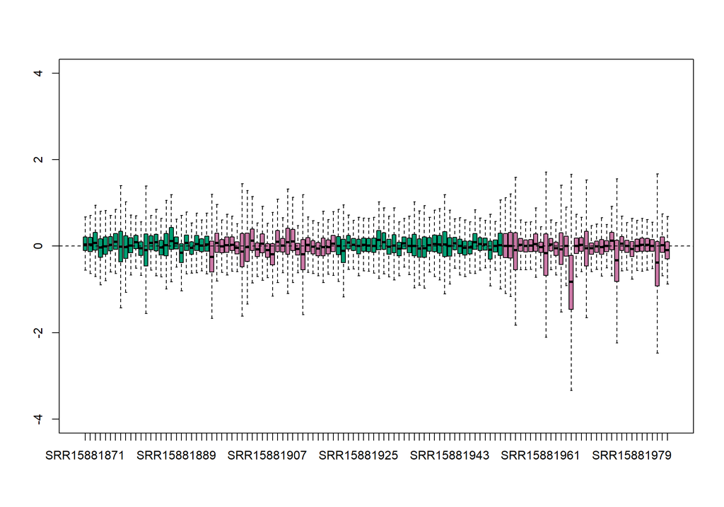

```r
plotRLE(ruv_pre_tmm_cpm, outline = FALSE, ylim = c(-4, 4), col = ruv_sample_colors)
```

## PCA Before TMM Normalization

PCA of logCPM before normalisation, coloured by timepoint.

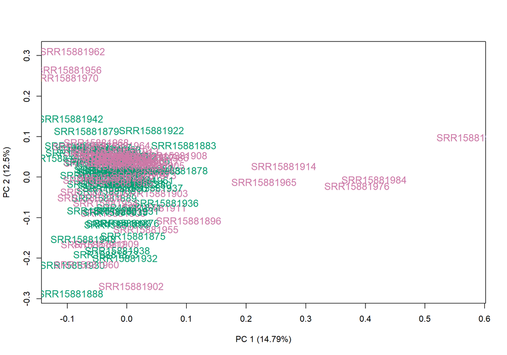

```r
plotPCA(ruv_pre_tmm_logcpm, isLog = TRUE, col = ruv_sample_colors, cex = 1.2)
```

## TMM Normalization

TMM (trimmed mean of M-values) normalisation in edgeR estimates scaling factors that adjust library sizes for differences in RNA composition between libraries. CPM and logCPM were then recalculated with the same settings using the TMM-adjusted library sizes, so the plots before and after TMM differ only in the normalisation factors.

```r
ruv_y <- normLibSizes(ruv_y, method = "TMM")
ruv_tmm_cpm <- cpm(ruv_y, log = FALSE, normalized.lib.sizes = TRUE)
ruv_tmm_logcpm <- cpm(ruv_y, log = TRUE, normalized.lib.sizes = TRUE)
```

## RLE After TMM Normalization

As above, using TMM-normalised CPM.

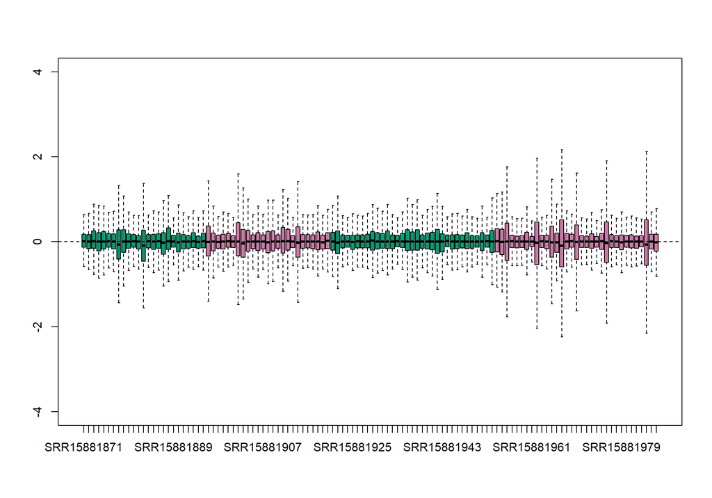

```r
plotRLE(ruv_tmm_cpm, outline = FALSE, ylim = c(-4, 4), col = ruv_sample_colors)
```

## PCA After TMM Normalization

As above, using TMM-normalised logCPM.

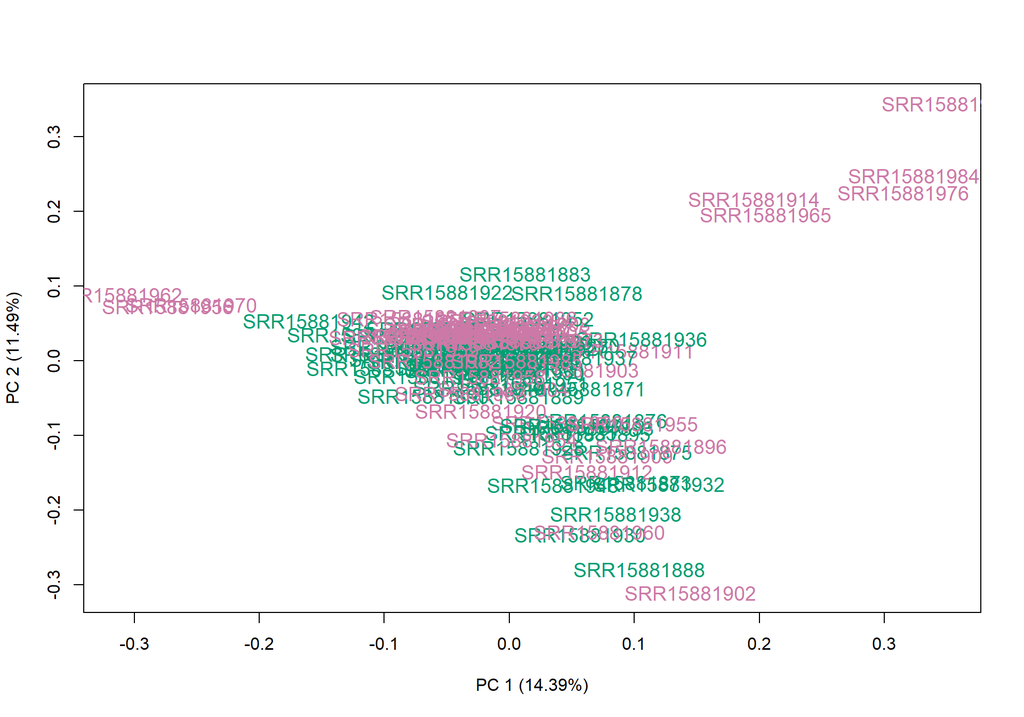

```r
plotPCA(ruv_tmm_logcpm, isLog = TRUE, col = ruv_sample_colors, cex = 1.2)
```

## First-pass edgeR Analysis

RUVg needs negative-control genes that are not affected by the effects of interest. To choose them empirically, a first-pass edgeR quasi-likelihood model with terms for individual, timepoint and case at follow-up was fitted to the counts, using the TMM normalisation factors. Genes were ranked by a joint test of the timepoint and case-at-follow-up coefficients.

```r
control_design <- model.matrix(~ individual + timepoint + case_followup, data = ruv_pheno)
control_fit <- glmQLFit(ruv_y, design = control_design, legacy = FALSE)
control_test_coef <- grep("^(timepoint|case_followup)", colnames(control_design))
stopifnot(length(control_test_coef) == 2)
control_test <- glmQLFTest(control_fit, coef = control_test_coef)
control_ranking <- topTags(control_test, n = Inf, sort.by = "PValue")$table |>
  as.data.frame() |>
  rownames_to_column("gene_id")
```

## Empirical Control Genes

Two empirical control sets were defined from this ranking:

- **Exclude top 5000**: all genes except the 5,000 most significant, as in the RUVSeq vignette
- **Bottom 50%**: the least significant half of the ranked genes

```r
top5000_genes <- control_ranking |>
  slice_head(n = min(5000, nrow(control_ranking))) |>
  pull(gene_id)
empirical_controls_exclude5000 <- setdiff(rownames(ruv_counts), top5000_genes)
empirical_controls_bottom50 <- control_ranking |>
  slice_tail(n = floor(nrow(control_ranking) * 0.5)) |>
  pull(gene_id) |>
  intersect(rownames(ruv_counts))
control_sets <- list(exclude_top5000 = empirical_controls_exclude5000, bottom50 = empirical_controls_bottom50)
control_labels <- c(exclude_top5000 = "Exclude top 5000", bottom50 = "Bottom 50%")
tibble(`Control strategy` = unname(control_labels[names(control_sets)]),
  `Genes ranked` = nrow(control_ranking),
  `Control genes` = lengths(control_sets)) |>
  reactable(pagination = FALSE, bordered = TRUE, striped = TRUE, highlight = TRUE)
```

| Control strategy | Genes ranked | Control genes |
| --- | --- | --- |
| Exclude top 5000 | 15018 | 10018 |
| Bottom 50% | 15018 | 7509 |

## RUVg Across k = 1 to 10

RUVg was run on the TMM-normalised logCPM (`isLog = TRUE`, `round = FALSE`) with each control set and `k = 1-10`, where `k` is the number of unwanted factors estimated.

```r
ruv_k_values <- 1:10
## With isLog = TRUE, normalizedCounts stay on the logCPM scale and go straight into PCA
ruv_fits <- purrr::map(control_sets, function(controls) {
  purrr::map(ruv_k_values, function(k) RUVg(ruv_tmm_logcpm, controls, k = k, isLog = TRUE, round = FALSE)) |>
    setNames(paste0("k", ruv_k_values))})
```

## PCA Across Empirical Control Strategies

PCA (centred, not scaled) was run on the RUVg-normalised logCPM for each control set and value of `k`. Points and ellipses are coloured by disease state, with point shape and line type showing timepoint. Ellipses are drawn at the 95% level for each combination of disease state and timepoint.

```r
ruv_pca_data <- purrr::imap_dfr(ruv_fits, function(control_fits, control_id) {
  purrr::map_dfr(ruv_k_values, function(k) {
    pca_k <- prcomp(t(control_fits[[paste0("k", k)]]$normalizedCounts), center = TRUE, scale. = FALSE)
    variance_k <- (pca_k$sdev^2 / sum(pca_k$sdev^2)) * 100
    as.data.frame(pca_k$x[, 1:2, drop = FALSE]) |>
      rownames_to_column("run") |>
      mutate(control_id = control_id, control_method = unname(control_labels[control_id]), k = k,
        pc1_variance = variance_k[1], pc2_variance = variance_k[2])
  })}) |>
  left_join(sample_info, by = "run") |>
  mutate(disease_state = factor(disease_state, levels = c("control", "T2D case")),
    timepoint = factor(timepoint, levels = c("baseline", "follow-up")))
```

```r
## Use common axis limits across all k values and control sets
ruv_pc1_lim <- c(-1, 1) * max(abs(ruv_pca_data$PC1))
ruv_pc2_lim <- c(-1, 1) * max(abs(ruv_pca_data$PC2))
plot_ruv_pca_tabs <- function(control_id_selected) {
  for (k_value in ruv_k_values) {
    ruv_pca_k <- ruv_pca_data |>
      dplyr::filter(control_id == control_id_selected, k == k_value)
    cat("\n\n#### k = ", k_value, "\n\n", sep = "")
    p <- ggplot(ruv_pca_k, aes(x = PC1, y = PC2, color = disease_state, shape = timepoint)) +
      stat_ellipse(aes(group = interaction(disease_state, timepoint), color = disease_state, linetype = timepoint),
        level = 0.95, linewidth = 0.8) +
      geom_point(size = 2.8, alpha = 0.85) +
      scale_color_manual(values = disease_colors) +
      scale_shape_manual(values = c("baseline" = 19, "follow-up" = 21)) +
      scale_linetype_manual(values = c("baseline" = "solid", "follow-up" = "dashed")) +
      labs(x = paste0("PC1 (", round(ruv_pca_k$pc1_variance[1], 1), "%)"),
        y = paste0("PC2 (", round(ruv_pca_k$pc2_variance[1], 1), "%)"),
        color = "Disease state", shape = "Timepoint", linetype = "Timepoint") +
      coord_cartesian(xlim = ruv_pc1_lim, ylim = ruv_pc2_lim) +
      cchc_theme()
    print(p)
  }}
```

### Exclude Top 5000

```r
plot_ruv_pca_tabs("exclude_top5000")
```

#### k = 1

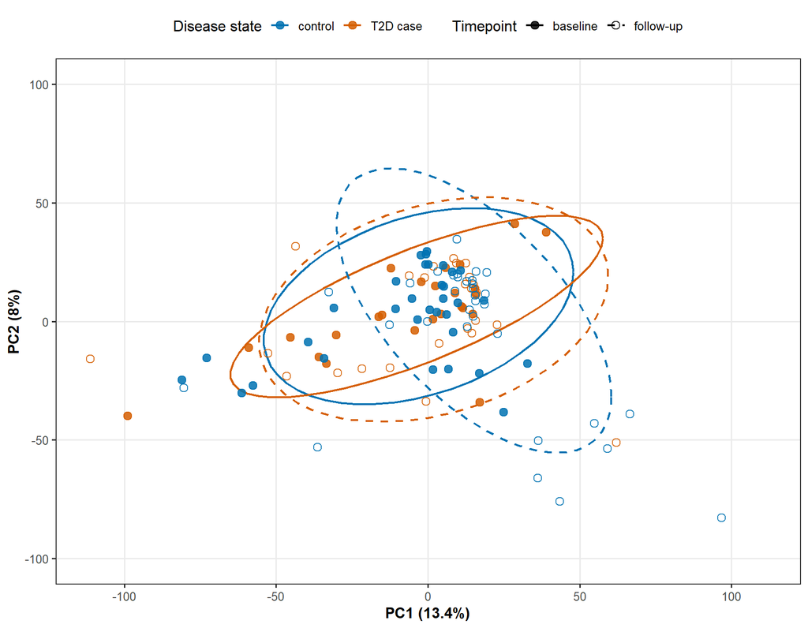

#### k = 2

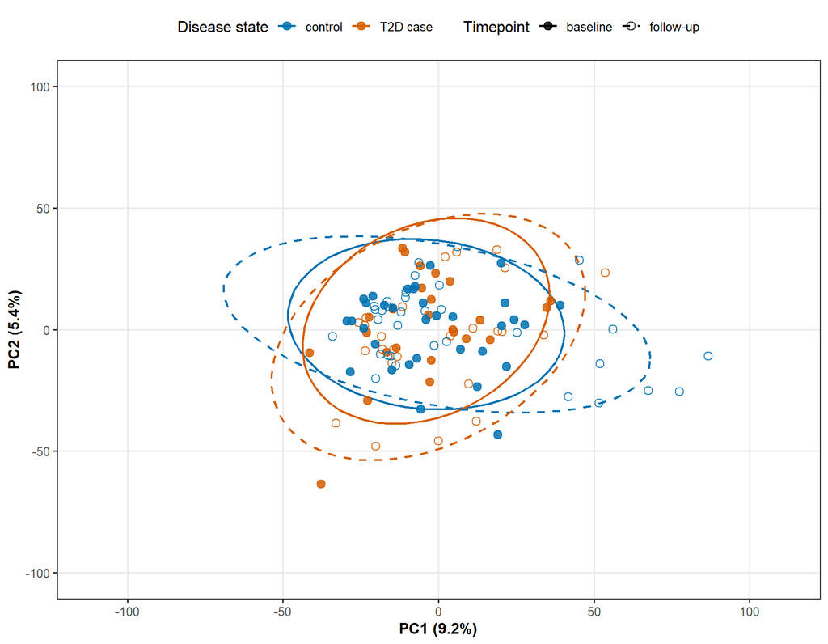

#### k = 3

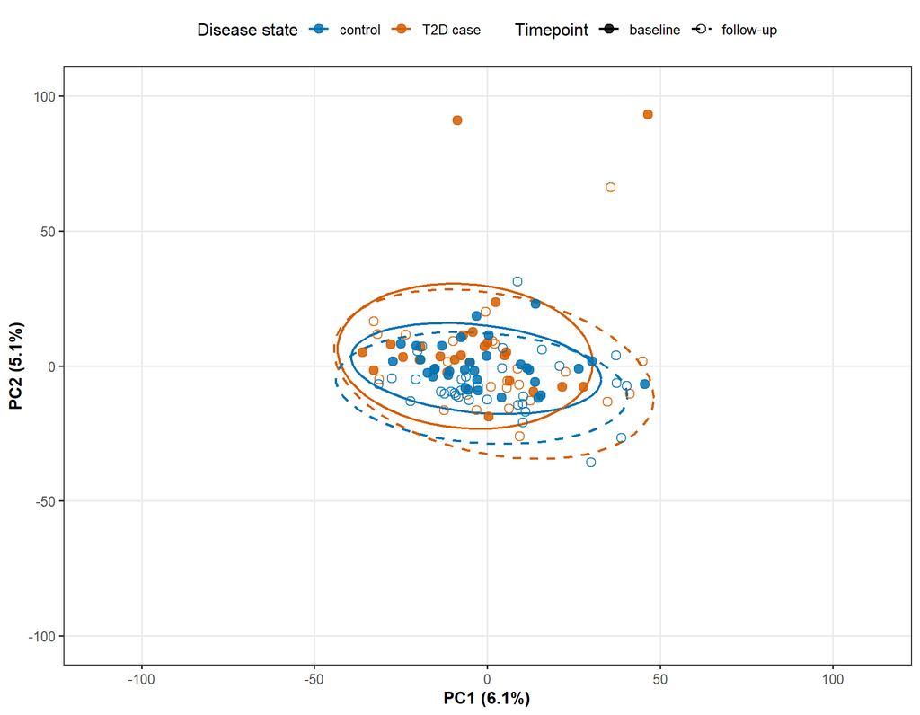

#### k = 4

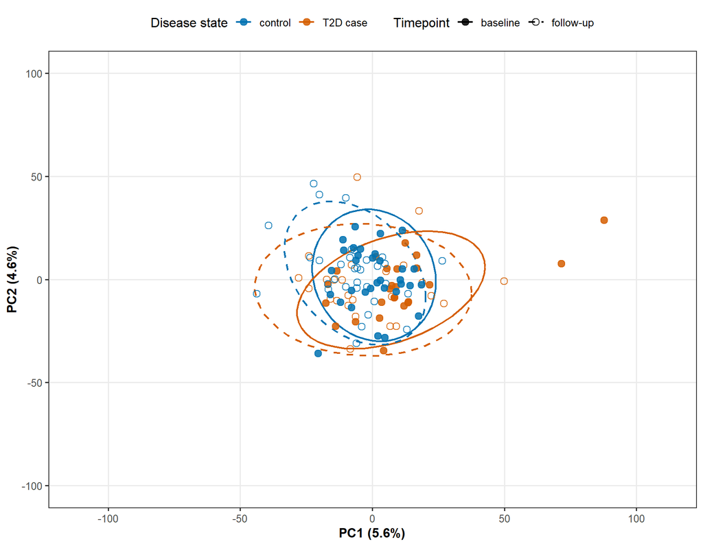

#### k = 5

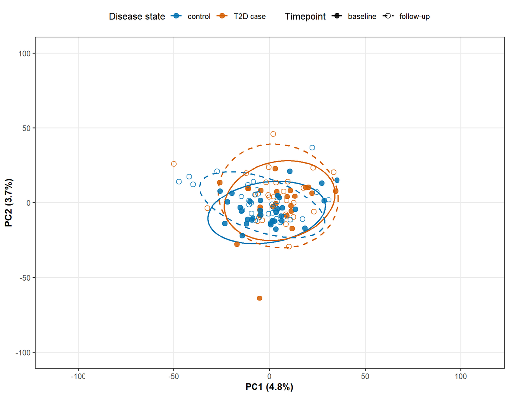

#### k = 6

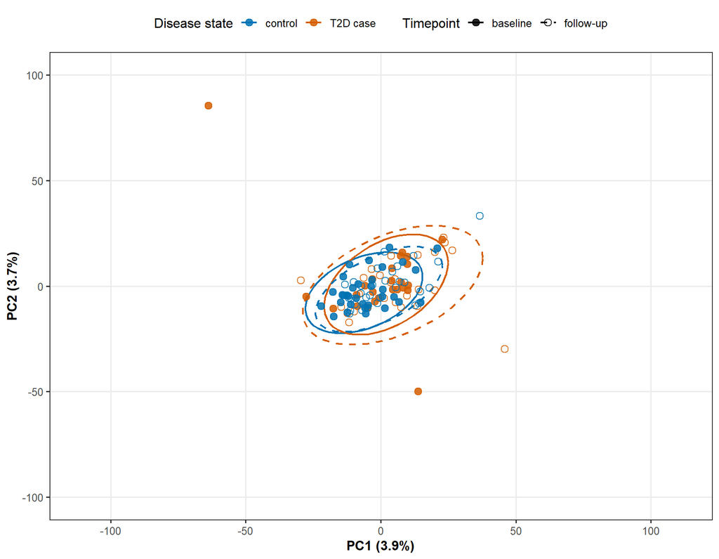

#### k = 7

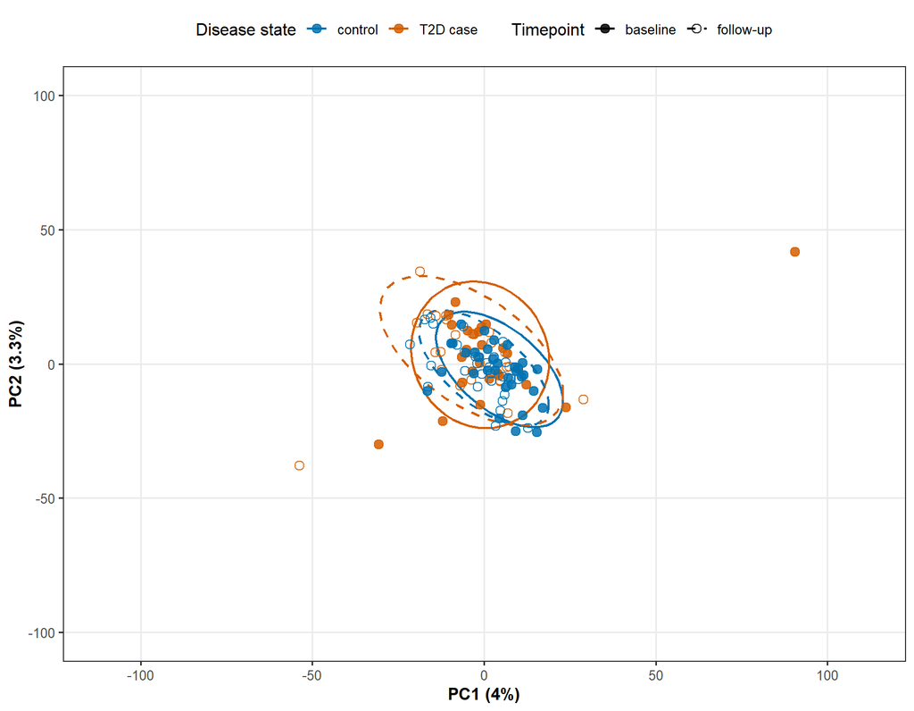

#### k = 8

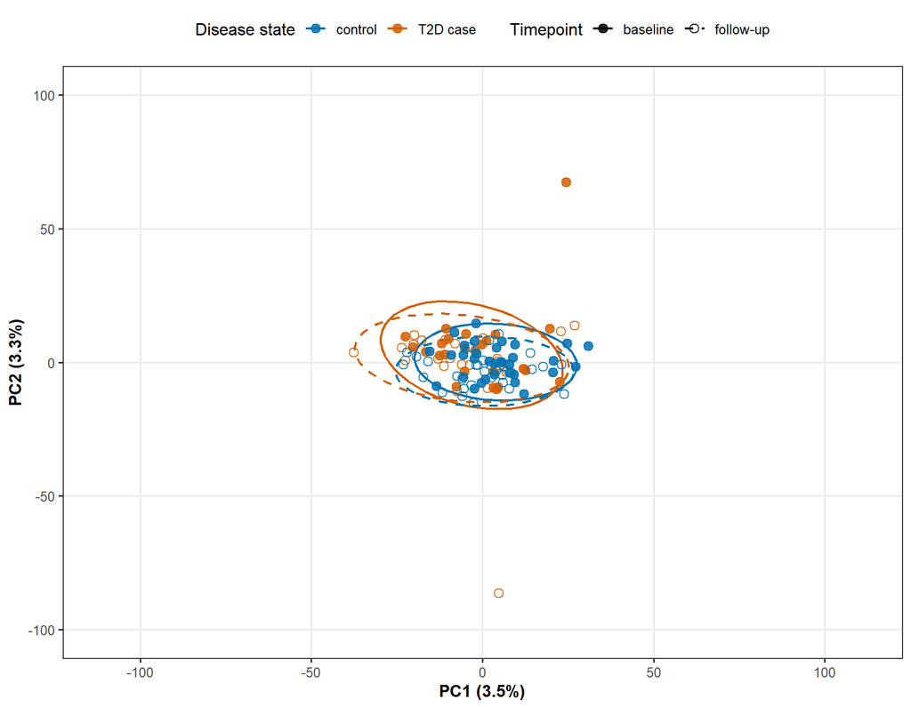

#### k = 9

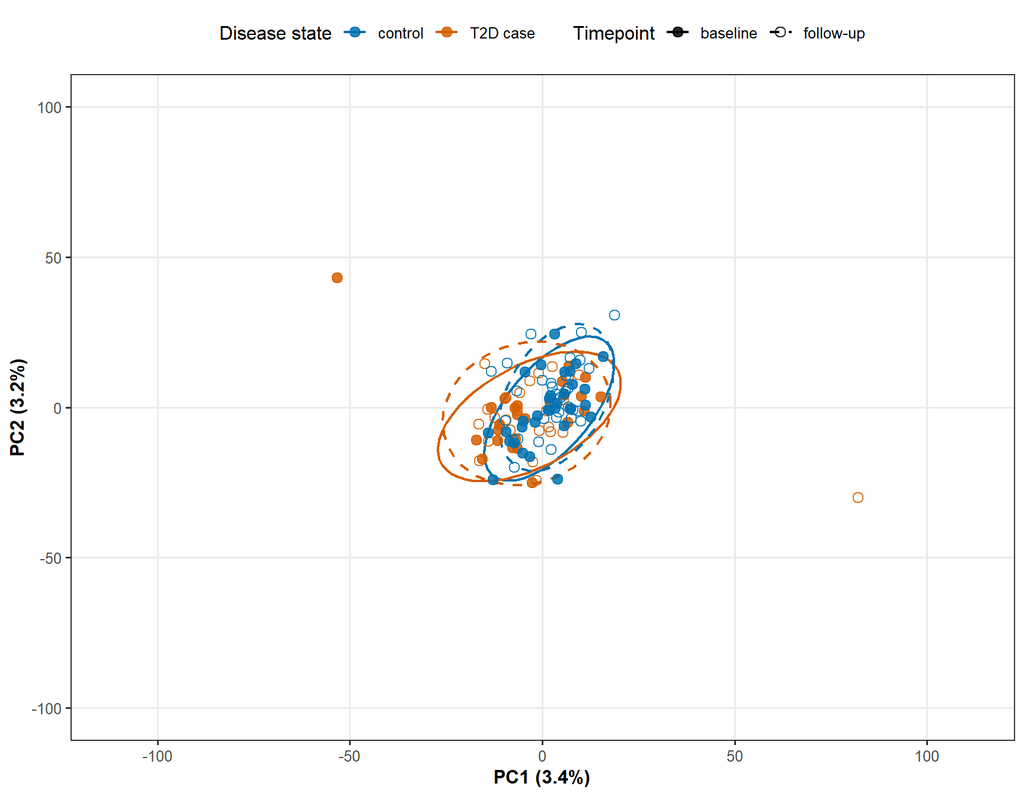

#### k = 10

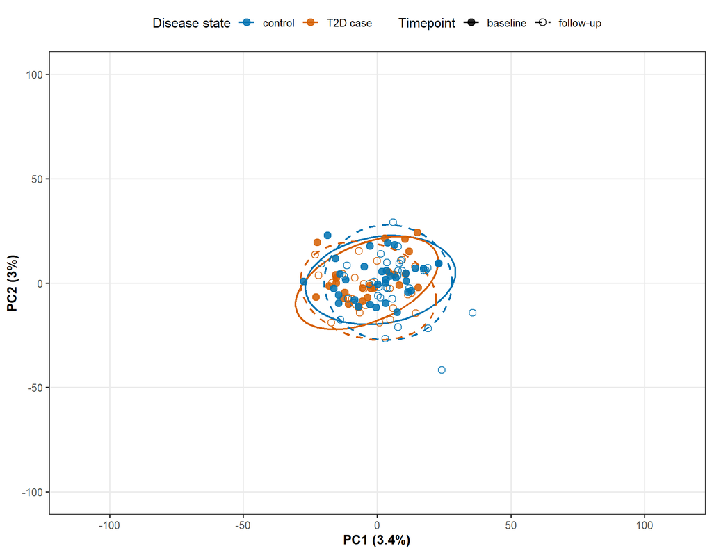

### Bottom 50%

```r
plot_ruv_pca_tabs("bottom50")
```

#### k = 1

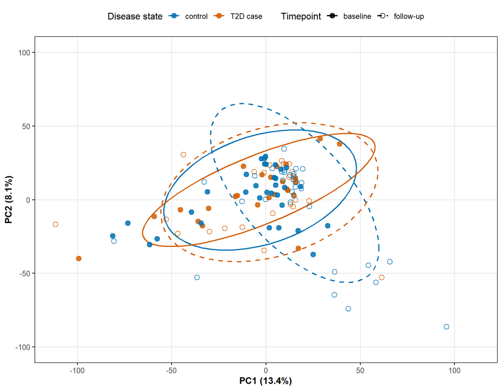

#### k = 2

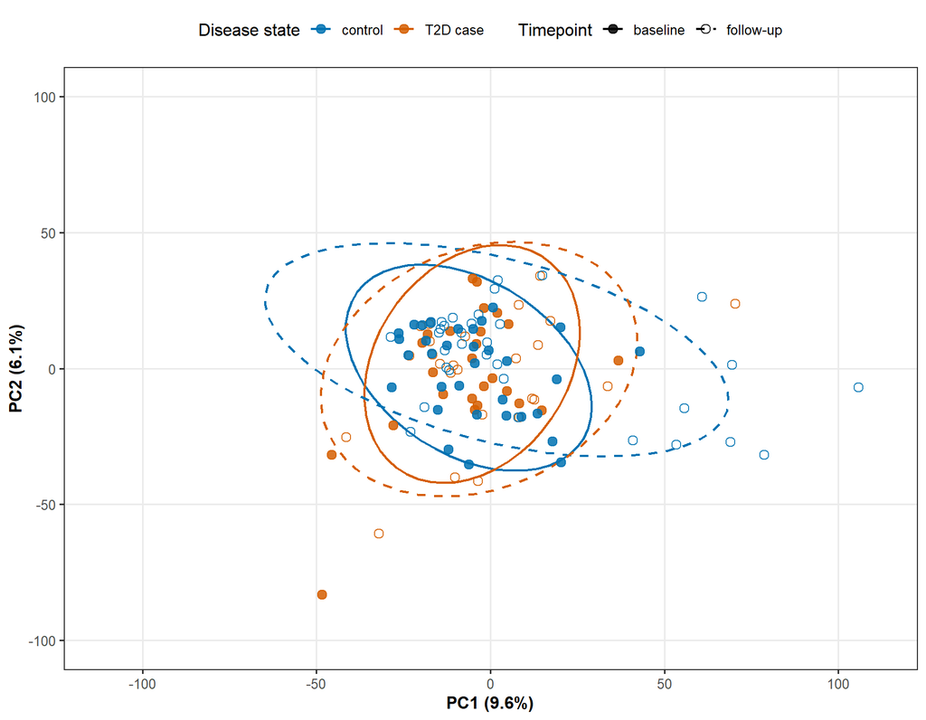

#### k = 3

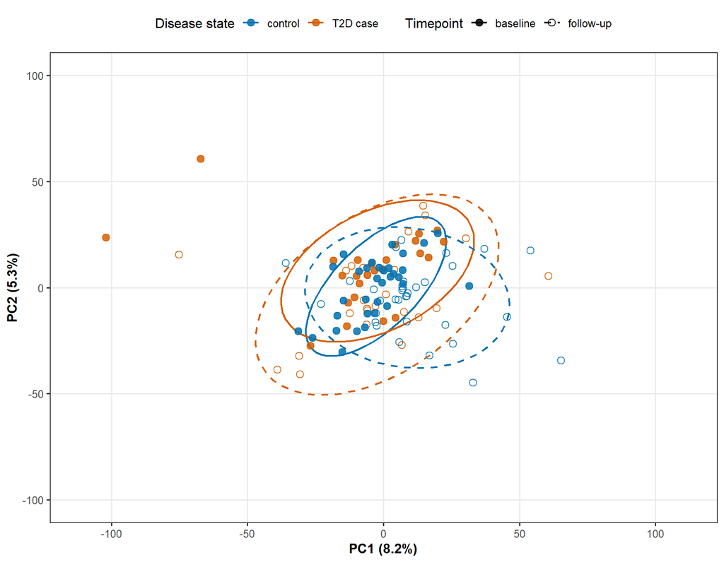

#### k = 4

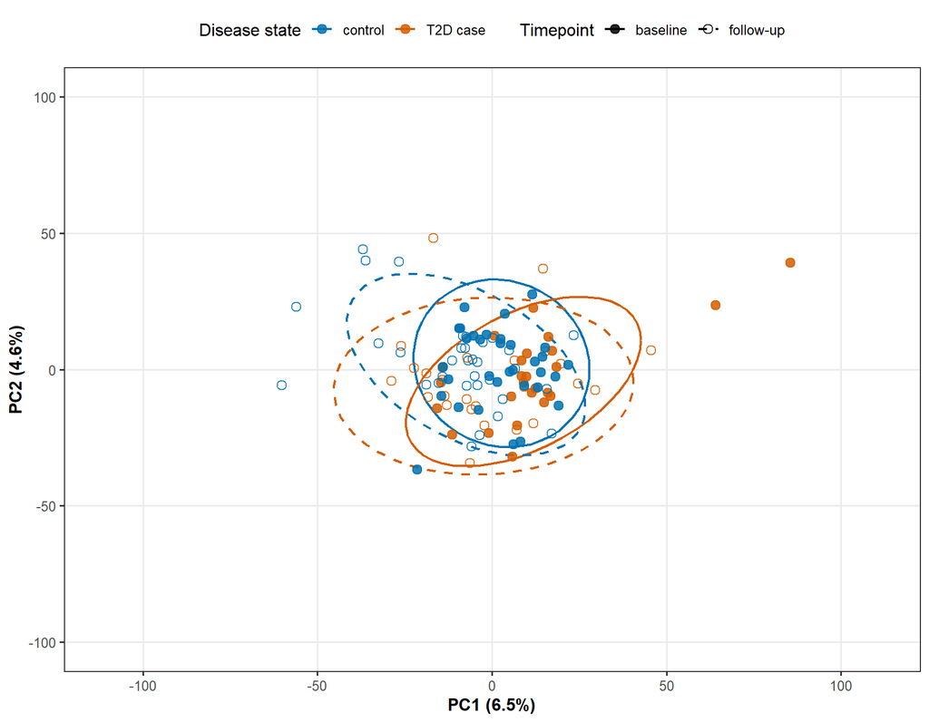

#### k = 5

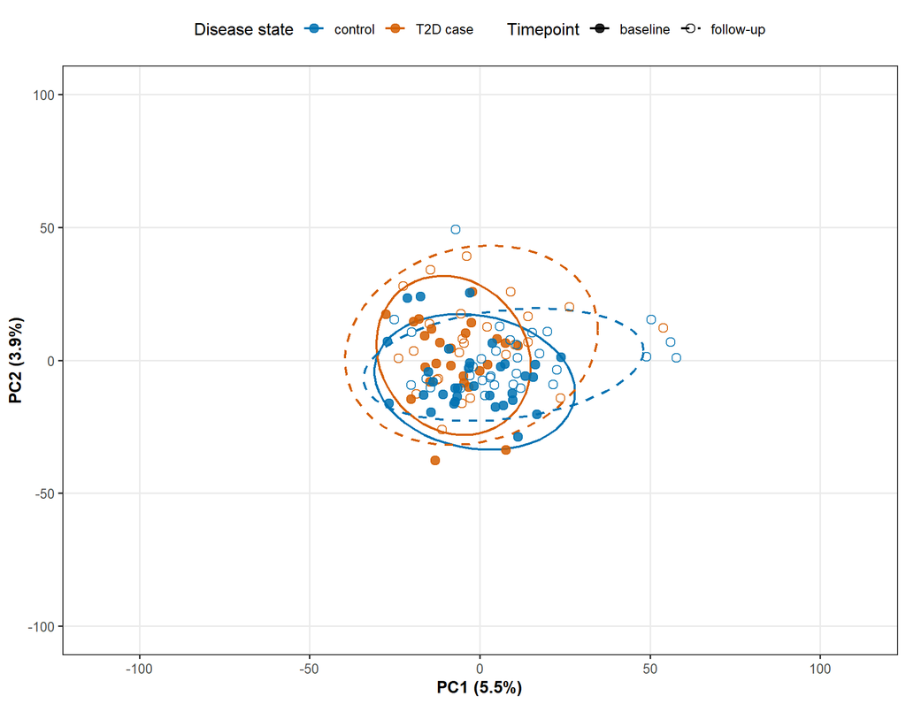

#### k = 6

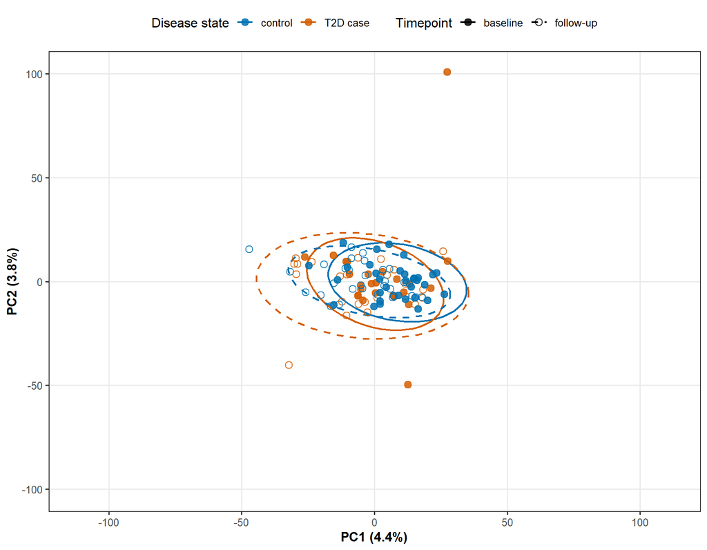

#### k = 7

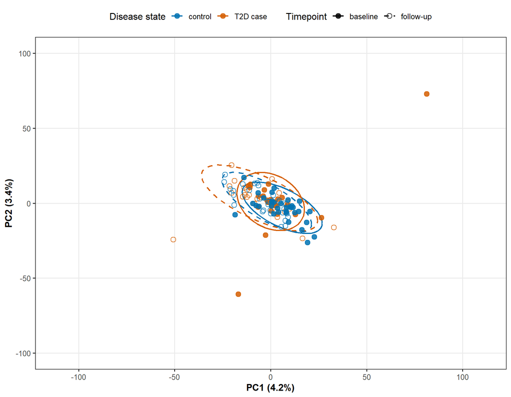

#### k = 8

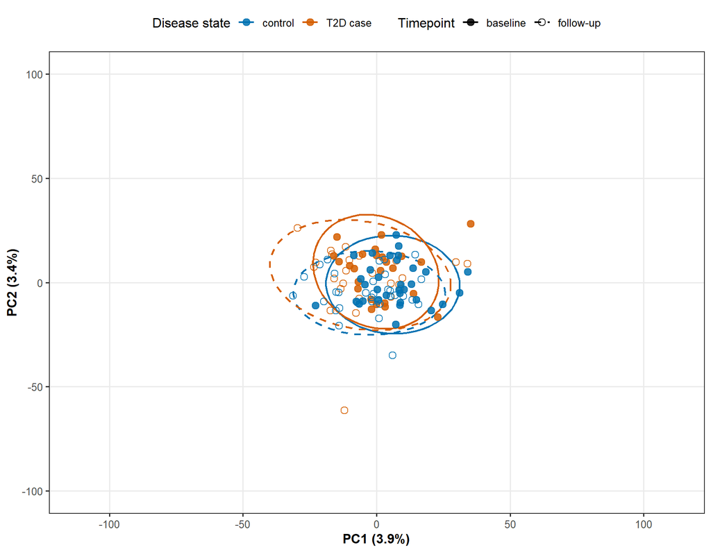

#### k = 9

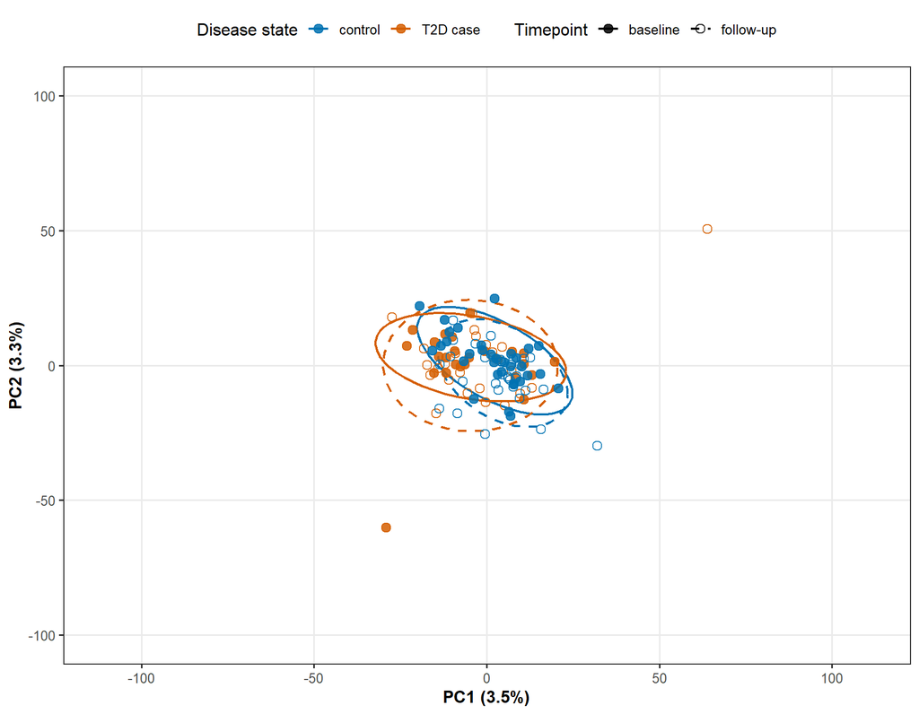

#### k = 10

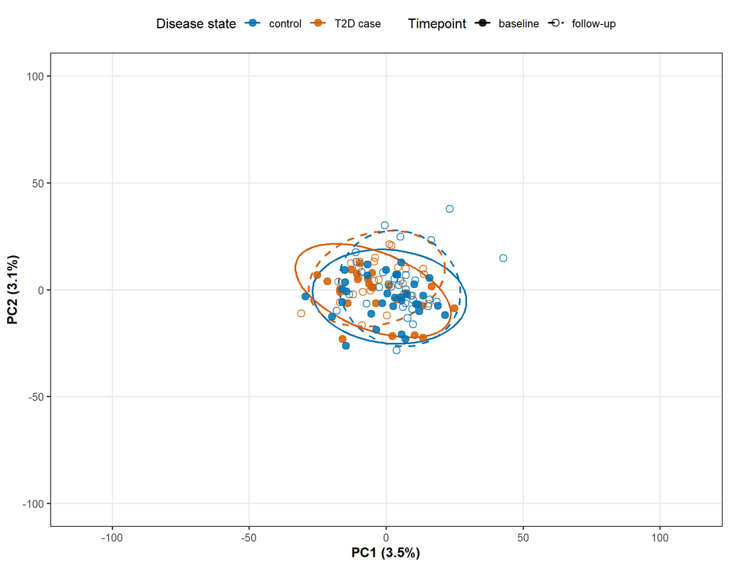